# ЛІНІЙНІ МОДЕЛІ. ЧАСТИНА IІ - КЛАСИФІКАЦІЯ

## 1. Визначення та задачі моделей класифікації

## 2. Метрики якості класифікаці моделей МН

## 3. Моделі класифікації в бібліотеці sklearn-kit

## 1. Визначення та задачі моделей класифікації

[**Класифікація**](https://evergreens.com.ua/ua/articles/classical-machine-learning.html) — це тип *навчання з вичителем*, який передбачає прогнозування класу або категорії заданої точки по її вхідним даним.

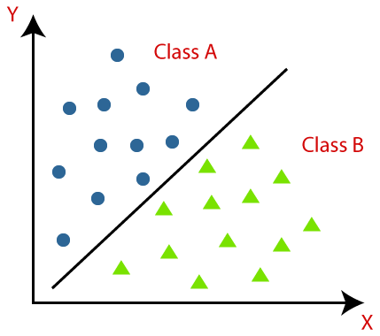

**Метою** моделей класифікації є прогнозування класу або категорії заданої точки вхідних даних.

Це досягається шляхом вивчення межі рішення або набору правил, які можна використовувати для класифікації нових, невидимих точок даних в один із кількох попередньо визначених класів або категорій.

В задачах класифікації цілова змінна - **завжди** є *категоріальною*.

### ТИПИ МОДЕЛЕЙ КЛАСИФІКАЦІЇ

- [**Логістична регресія**](https://uk.wikipedia.org/wiki/%D0%9B%D0%BE%D0%B3%D1%96%D1%81%D1%82%D0%B8%D1%87%D0%BD%D0%B0_%D1%80%D0%B5%D0%B3%D1%80%D0%B5%D1%81%D1%96%D1%8F): популярний і простий алгоритм класифікації, який моделює **ймовірність** двійкової або багатокласової вихідної змінної з урахуванням вхідних характеристик.
- [**Дерева рішень**](https://uk.wikipedia.org/wiki/%D0%94%D0%B5%D1%80%D0%B5%D0%B2%D0%BE_%D1%83%D1%85%D0%B2%D0%B0%D0%BB%D0%B5%D0%BD%D0%BD%D1%8F_%D1%80%D1%96%D1%88%D0%B5%D0%BD%D1%8C): алгоритм класифікації на основі дерева, який *рекурсивно* розбиває вхідний датасет на менші області, де кожна область відповідає певному класу.
- [**Наивний Байєс**](https://uk.wikipedia.org/wiki/%D0%9D%D0%B0%D1%97%D0%B2%D0%BD%D0%B8%D0%B9_%D0%B1%D0%B0%D1%94%D1%81%D1%96%D0%B2_%D0%BA%D0%BB%D0%B0%D1%81%D0%B8%D1%84%D1%96%D0%BA%D0%B0%D1%82%D0%BE%D1%80): алгоритм імовірнісної класифікації, який припускає, що вхідні ознаки є умовно незалежними з урахуванням вихідної мітки.
- **Випадковий ліс**: алгоритм ансамблевої класифікації на основі дерева, який поєднує кілька дерев рішень для покращення продуктивності класифікації та зменшення надмірного оснащення.
- [**Випадковий ліс**](https://uk.wikipedia.org/wiki/Random_forest): алгоритм [ансамблевої класифікації](https://en.wikipedia.org/wiki/Ensemble_learning) на основі дерева, який поєднує кілька дерев рішень для покращення продуктивності класифікації та зменшення надмірного перенавчання.
- [**K-найближчі сусіди (KNN)**](https://uk.wikipedia.org/wiki/%D0%9C%D0%B5%D1%82%D0%BE%D0%B4_k-%D0%BD%D0%B0%D0%B9%D0%B1%D0%BB%D0%B8%D0%B6%D1%87%D0%B8%D1%85_%D1%81%D1%83%D1%81%D1%96%D0%B4%D1%96%D0%B2): непараметричний алгоритм класифікації, який призначає найпоширеніший клас серед K-найближчих сусідів даної точки вхідних даних у навчальному наборі даних.
- [**. . .**](https://towardsdatascience.com/top-machine-learning-algorithms-for-classification-2197870ff501)

Моделі класифікації використовуються в широкому діапазоні длдатків, таких як

- [класифікація зображень](https://www.sciencedirect.com/topics/engineering/image-classification),
- [аналіз настроїв](https://uk.wikipedia.org/wiki/%D0%90%D0%BD%D0%B0%D0%BB%D1%96%D0%B7_%D1%82%D0%BE%D0%BD%D0%B0%D0%BB%D1%8C%D0%BD%D0%BE%D1%81%D1%82%D1%96_%D1%82%D0%B5%D0%BA%D1%81%D1%82%D1%83),
- [виявлення спаму](https://towardsdatascience.com/email-spam-detection-1-2-b0e06a5c0472),
- [виявлення шахрайства](https://www.ravelin.com/insights/machine-learning-for-fraud-detection)
- . . .

## 2. Метрики якості класифікаці моделей МН

**Основні метрики** классифікації:

- **Достовірність**: вимірює частку правильних прогнозів, зроблених моделлю серед усіх прогнозів. Зазвичай використовується, коли класи збалансовані та однаково важливі.
- **Точність**: вимірює частку справжніх позитивних прогнозів, зроблених моделлю серед усіх позитивних прогнозів.

Зазвичай використовується, коли вартість хибних прогнозів висока, і метою є їх мінімізація.

- **Відгук** - він вимірює частку справжніх позитивних прогнозів, зроблених моделлю серед усіх фактичних позитивних випадків у наборі даних.

Він зазвичай використовується, коли вартість хибно негативних результатів висока, і метою є мінімізація помилкових негативних прогнозів.

- **Оцінка F1**: це зважене гармонічне середнє значення точності та відгуку.

Його зазвичай використовують, коли і точність, і відгук однаково важливі.

- [**Крива ROC і AUC**](https://uk.wikipedia.org/wiki/ROC-%D0%BA%D1%80%D0%B8%D0%B2%D0%B0): крива робочої характеристики приймача (Receiver Operating Characteristic) (ROC) є графіком істинної позитивної частоти (True Positive Rate) проти помилкової позитивної частоти (False Positive Rate) при різних порогових значеннях. Площа під кривою ROC (AUC) — число, яке вимірює загальну продуктивність класифікатора, і воно варіюється від 0 до 1, причому вищі значення вказують на кращу якість моделі.

Аналіз класифікацій із застосуванням ROC-кривих називається **ROC-аналізом**.

- [**Матриця плутанини (Confusion Matrix)**](https://en.wikipedia.org/wiki/Confusion_matrix): таблиця, яка показує кількість справжніх позитивних результатів (**TP**), помилкових позитивних результатів (**FP**), справжніх негативних результатів (**TN**) і помилкових негативних результатів (**FN**) для даної моделі класифікації.

Він зазвичай використовується для візуалізації продуктивності класифікатора та розрахунку різних показників, таких як *достовірність*, *точність* і *відгук*.

[**Перелік**](https://scikit-learn.org/stable/modules/model_evaluation.html#classification-metrics) метрик для оцінювання якості моделей класифікації в бібліотеці `sklearn-kit`

## 3. Лінійні моделі класифікації в бібліотеці sklearn-kit

- **Логістична регресія**: це широко використовувана лінійна модель для бінарної класифікації, де цільова змінна є двійковою (0 або 1). Логістична регресія оцінює ймовірність того, що цільова змінна дорівнює 1, враховуючи вхідні характеристики.
- **Машини опорних векторів** (SVM) - лінійна модель, яка використовується для двійкової та багатокласової класифікації.

SVM знаходять гіперплощину, яка максимізує зазор між двома класами. *Зазор* – це відстань між гіперплощиною та найближчими точками даних з кожного класу.

- **Лінійний дискримінантний аналіз** (LDA) - це лінійна модель, яка використовується для багатокласової класифікації, де цільова змінна може приймати більше двох значень. LDA проектує вхідні дані на низьковимірний простір і знаходить лінійні межі між класами.

### Логістична регресія

[**Логістична регресія**](https://uk.wikipedia.org/wiki/%D0%9B%D0%BE%D0%B3%D1%96%D1%81%D1%82%D0%B8%D1%87%D0%BD%D0%B0_%D1%80%D0%B5%D0%B3%D1%80%D0%B5%D1%81%D1%96%D1%8F) — це популярний алгоритм машинного навчання, який використовується для побудови моделей [бінарної](https://en.wikipedia.org/wiki/Binary_classification) та [багатокласової](https://en.wikipedia.org/wiki/Multiclass_classification) класифікації.

Це тип навчання з вчителем, мета якого полягає в тому, щоб дізнатися поріг прийняття рішення, який може розділити вхідні дані на різні класи або категорії.

Логістична регресія припускає, що цільова змінна є *двійковою* або *категоріальною* за своєю природою, і вона моделює **ймовірність** належності вхідних даних до кожного класу.

Результатом алгоритму є *прогнозована ймовірність* належності вхідних даних до кожного класу, яка потім обмежується порогом, щоб призначити вхідні дані певному класу.

**Рівняння логістичної регресії ([сигмоїда](https://uk.wikipedia.org/wiki/%D0%A1%D0%B8%D0%B3%D0%BC%D0%BE%D1%97%D0%B4%D0%B0))**

$$p(y=1 | \boldsymbol{X}; b, \boldsymbol{\theta}) = \frac{1}{1 + e^{-(b + \boldsymbol{\theta}^T\boldsymbol{X})}}$$

$p(y=1 | \boldsymbol{X}; b, \boldsymbol{\theta})$ є прогнозованою ймовірністю того, що вихідна змінна $y$ дорівнює **1** із заданим вхідним вектором $\boldsymbol{X}$, параметром зміщення $b$,та параметрами моделі $\boldsymbol{\theta}$.

$\boldsymbol{b}$ - параметр зміщення

$\boldsymbol{\theta}$ є вектором параметрів або ваг моделі

$\boldsymbol{X}$ є вхідним вектором або вектором ознак

$$\Tiny p(y=1 | \boldsymbol{X}; b, \boldsymbol{\theta}) = \frac{1}{1 + e^{-(b + \boldsymbol{\theta}^T\boldsymbol{X})}}$$

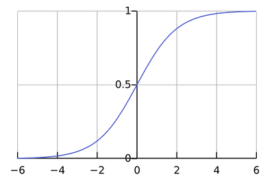

[Пояснення](https://ai.plainenglish.io/why-is-logistic-regression-called-regression-if-it-is-a-classification-algorithm-9c2a166e7b74) терміну 'регресія' в класифікаторах на моделі логістичної регресії

### ПРИКЛАД

```python
import pandas as pd
import numpy as np
from sklearn.datasets import make_classification

# хелпер для побудови синтетичного датасету на n-х параметрах з 100 елементів
def make_datasets(count_x, balance, noise):
    '''balance - масив часток кожного класу в датасеті
       noise - частка шуму в датасеті, count_x - кількість незалежних змінних'''
    return make_classification(n_samples=100, n_features=count_x, n_redundant=0,
                           n_informative=1, n_clusters_per_class=1,
                           weights=balance, flip_y=noise,
                           class_sep=1, random_state=42)
```

```python
X, y = make_datasets(count_x=2, balance=[.9, .1,], noise=0.1)
```

```python
# формуємо датафрейм з кількістю спостережень кожного класу
class_name, class_count = np.unique(y, return_counts=True)
y_total = pd.DataFrame({'кількість значень' : class_count})
```

```python
y_total
```

|  | кількість значень |
| --- | --- |
| 0 | 84 |
| 1 | 16 |

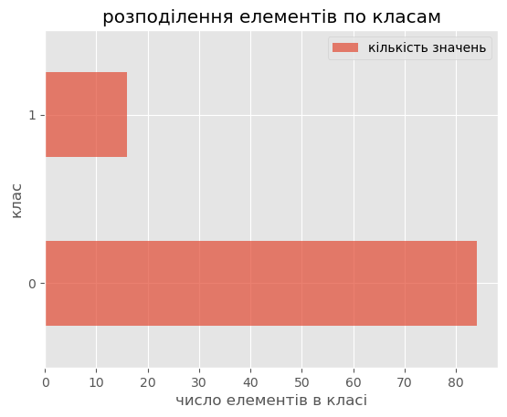

```python
import matplotlib.pyplot as plt
with plt.style.context('ggplot'):
    y_total.plot.barh(alpha=.7)
    plt.title('розподілення елементів по класам')
    plt.xlabel('число елементів в класі')
    plt.ylabel('клас')
    plt.show()
```

```python
# будуємо класифікатор
from sklearn.linear_model import LogisticRegression
logreg = LogisticRegression(penalty='l2', C=100, random_state=42)
```

```python
# тренуємо класифікатор
_ = logreg.fit(X, y)
```

```python
print(f'коєфіцієнти логістичного рівняння: {logreg.coef_[0].round(2)}')
```

```
коєфіцієнти логістичного рівняння: [-0.48  2.42]
```

**Поріг прийняття рішення** [(deсision threshold)](https://www.iguazio.com/glossary/classification-threshold/) - це значення, яке використовується для визначення класифікації прогнозованої ймовірності в одну з двох категорій.

Поріг прийняття рішення для *бінарної* логістичної регресії встановлено в **0.5**

```python
# вибираємо стратегію валідації
from sklearn.model_selection import ShuffleSplit
cv = ShuffleSplit(n_splits=10, random_state=42)
```

```python
# валідуємо його якість
from sklearn.model_selection import cross_validate, cross_val_score
from sklearn.metrics import balanced_accuracy_score

print(f'достовірність класифікації на навчанні = {logreg.score(X, y):.2f}')

accuracy = cross_val_score(logreg, X, y, scoring='accuracy', cv=cv)
print(f'достовірність класифікації на крос-валідації = {accuracy.mean():.2f}')

balanced_accuracy = balanced_accuracy_score(y, logreg.predict(X))
print(f'збалансована достовірність класифікації = {balanced_accuracy:.2f}')
```

```
достовірність класифікації на навчанні = 0.92
достовірність класифікації на крос-валідації = 0.94
збалансована достовірність класифікації = 0.78
```

#### Матриця помилок (Confusion Matrix)

```python
from sklearn.metrics import confusion_matrix, ConfusionMatrixDisplay
# confusion_matrix?
```

```python
# будуємо прогноз
y_pred = logreg.predict(X)
```

```python
# будуємо матрицю помилок
cm = confusion_matrix(y, y_pred)
```

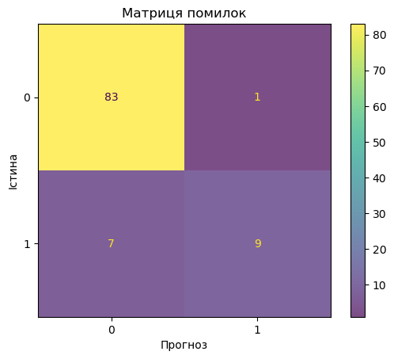

```python
disp = ConfusionMatrixDisplay(confusion_matrix=cm)
disp.from_estimator(logreg, X, y, im_kw={'alpha':.7})
plt.xlabel('Прогноз')
plt.ylabel('Істина')
plt.title('Матриця помилок')
plt.show()
```

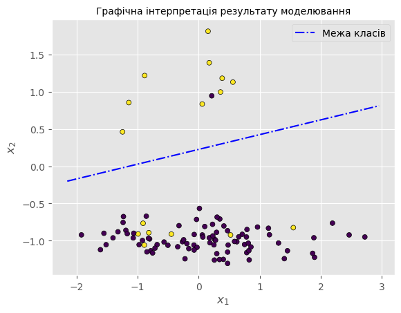

```python
with plt.style.context('ggplot'):

    plt.scatter(X[:, 0], X[:, 1], marker="o", c=y, s=25, edgecolor="k")

    plt.xlabel('${x_1}$')
    plt.ylabel('${x_2}$')
    plt.title ('Графічна інтерпретація результату моделювання', fontdict={'fontsize': 10})
    x_min, x_max = plt.xlim()
    coef = logreg.coef_[0]
    intercept = logreg.intercept_
    y_calculated = (-intercept - coef[0] * np.linspace(x_min, x_max, 100) / coef[1])
    plt.plot(np.linspace(x_min, x_max, 100), y_calculated, 'b-.', label='Межа класів')
    plt.legend()
    plt.show()
```

```python
from sklearn.metrics import precision_score, recall_score, f1_score, \
                            accuracy_score, balanced_accuracy_score

accuracy = precision_score(y, y_pred)
precision = precision_score(y, y_pred)
recall = recall_score(y, y_pred)
f1 = f1_score(y, y_pred)
balanced_accuracy = balanced_accuracy_score(y, y_pred)

print(f"Достовірність класифікації:\t {accuracy:.3f}")
print(f"Точність класифікації:\t\t {precision:.3f}")
print(f"Відгук класифікації:\t\t {recall:.3f}")
print(f"f1-оцінка класифікації:\t\t {f1:.3f}\n", end='-'*38)
print(f"\nЗбалансована достовірність:\t {balanced_accuracy:.3f}")
```

[output not shown]

```python
# результати класифікації в вирогідностному представлені
pd.DataFrame(logreg.predict_proba(X), columns=logreg.classes_).head()
```

|  | 0 | 1 |
| --- | --- | --- |
| 0 | 0.838512 | 0.161488 |
| 1 | 0.868228 | 0.131772 |
| 2 | 0.928095 | 0.071905 |
| 3 | 0.948135 | 0.051865 |
| 4 | 0.969366 | 0.030634 |

```python
from sklearn.metrics import PrecisionRecallDisplay

disp = PrecisionRecallDisplay.from_estimator(logreg, X, y, pos_label=0, marker='.',
                                            linestyle='-')
disp = PrecisionRecallDisplay.from_estimator(logreg, X, y, pos_label=1, marker=".",
                                             ax=disp.ax_)
```

[output not shown]

### Машина опорних векторів SVM

[Машина опорних векторів](https://uk.wikipedia.org/wiki/%D0%9C%D0%B5%D1%82%D0%BE%D0%B4_%D0%BE%D0%BF%D0%BE%D1%80%D0%BD%D0%B8%D1%85_%D0%B2%D0%B5%D0%BA%D1%82%D0%BE%D1%80%D1%96%D0%B2) (SVM) — це алгоритм машинного навчання, який використовується для задач класифікації та регресії.

**Основні функції SVM**:

- SVM намагається знайти гіперплощину (лінійну чи нелінійну), яка розділяє різні класи з максимально можливим запасом (зазор). Запас визначається як відстань між гіперплощиною та найближчими точками даних кожного класу.

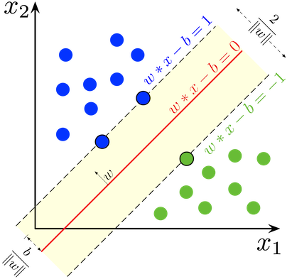

- SVM використовує **трюк з ядром** ([Kernel Trick](https://towardsdatascience.com/the-kernel-trick-c98cdbcaeb3f)), щоб відобразити дані у просторі з більшою вимірністю, де легше знайти роздільну гіперплощину. Це особливо корисно, коли дані не можна лінійно розділити у вихідному просторі.
- SVM менш чутливий до викидів, ніж деякі інші алгоритми машинного навчання, оскільки він намагається знайти максимальну гіперплощину запасу, на яку не впливають викиди, розташовані далеко від гіперплощини.
- SVM можна *регуляризувати* шляхом додавання штрафного коєфіцієнта, що допомагає уникнути перенавчання та покращити узагальнення.
- SVM може обробляти нелінійні дані за допомогою різних типів ядер, таких як поліноміальна, радіальна базисна функція (RBF) і сигмоїда.
- SVM добре працює з наборами даних *малого та середнього* розміру, але може не підходити для великих наборів даних через високу обчислювальну вартість.

**Достоїнства**:

- Ефективний у на великій кількості ознак.
- Ефективний, коли кількість ознак перевищує кількість зразків.
- Добре працює як з лінійними, так і з нелінійними даними.
- Толерантний до викидів.
- Може бути використаний як для двійкової, так і для багатокласової класифікації.
- Хороша якість узагальнення.

**Недоліки**:

- Досить чутливий до вибору функції ядра та гіперпараметрів.
- Обчислювально дорогий для великих наборів даних.
- Може бути схильний до перенавчання, якщо параметр регуляризації не налаштований належним чином.
- Інтерпретація результатів може бути складною.

### ПРИКЛАД

*Побудувати класифікатор для прогнозування значееня показчика 'раса' в датасеті 'adult-census.csv'*

```python
import pandas as pd
data = pd.read_csv('adult-census.csv')
data.head(3)
```

|  | age | workclass | education | education-num | marital-status | occupation | relationship | race | sex | capital-gain | capital-loss | hours-per-week | native-country | class |
| --- | --- | --- | --- | --- | --- | --- | --- | --- | --- | --- | --- | --- | --- | --- |
| 0 | 25 | Private | 11th | 7 | Never-married | Machine-op-inspct | Own-child | Black | Male | 0 | 0 | 40 | United-States | <=50K |
| 1 | 38 | Private | HS-grad | 9 | Married-civ-spouse | Farming-fishing | Husband | White | Male | 0 | 0 | 50 | United-States | <=50K |
| 2 | 28 | Local-gov | Assoc-acdm | 12 | Married-civ-spouse | Protective-serv | Husband | White | Male | 0 | 0 | 40 | United-States | >50K |

```python
# видалимо 'нетиповий' запис
cond = data['native-country'].str.contains('Holand-Netherlands')
data = data.drop(data[cond].index)
data = data.drop(columns=['education-num'])
```

```python
# вивести назви та кількість класів в покажчику 'race'
df_races = data.groupby(by='race')['race'].count().sort_values(ascending=False)
df_races
```

```
race
 White                 41761
 Black                  4685
 Asian-Pac-Islander     1519
 Amer-Indian-Eskimo      470
 Other                   406
Name: race, dtype: int64
```

[figure not shown]

```python
import matplotlib.pyplot as plt

with plt.style.context('ggplot'):
    df_races.plot(kind='bar', rot=45, alpha=.7, color='green')

    plt.title('Прорівняння кількості спостережень по расам')
    plt.xlabel('раси')
    plt.ylabel('кількість')

    plt.show()
```

#### Підготувати датасет

```python
data.info()
```

```
<class 'pandas.core.frame.DataFrame'>
Int64Index: 48841 entries, 0 to 48841
Data columns (total 13 columns):
 #   Column          Non-Null Count  Dtype
---  ------          --------------  -----
 0   age             48841 non-null  int64
 1   workclass       48841 non-null  object
 2   education       48841 non-null  object
 3   marital-status  48841 non-null  object
 4   occupation      48841 non-null  object
 5   relationship    48841 non-null  object
 6   race            48841 non-null  object
 7   sex             48841 non-null  object
 8   capital-gain    48841 non-null  int64
 9   capital-loss    48841 non-null  int64
 10  hours-per-week  48841 non-null  int64
 11  native-country  48841 non-null  object
 12  class           48841 non-null  object
dtypes: int64(4), object(9)
memory usage: 5.2+ MB
```

```python
target = data['race']
data = data.drop(columns=['race'])
data.shape, target.shape
```

```
((48841, 12), (48841,))
```

```python
from sklearn.compose import make_column_selector
cat_selector = make_column_selector(dtype_include='object')
category_columns = cat_selector(data)
num_selector = make_column_selector(dtype_exclude='object')
numeric_columns = num_selector(data)

category_columns, numeric_columns
```

```
(['workclass',
  'education',
  'marital-status',
  'occupation',
  'relationship',
  'sex',
  'native-country',
  'class'],
 ['age', 'capital-gain', 'capital-loss', 'hours-per-week'])
```

```python
from sklearn.preprocessing import OneHotEncoder

encoder = OneHotEncoder(handle_unknown='ignore')
data_encoded = encoder.fit_transform(data[category_columns])
df_encoded = pd.DataFrame(data_encoded.toarray())
df_encoded.columns=encoder.get_feature_names_out()
df_encoded.head(3)
```

|  | workclass_ ? | workclass_ Federal-gov | workclass_ Local-gov | workclass_ Never-worked | workclass_ Private | workclass_ Self-emp-inc | workclass_ Self-emp-not-inc | workclass_ State-gov | workclass_ Without-pay | education_ 10th | ... | native-country_ Scotland | native-country_ South | native-country_ Taiwan | native-country_ Thailand | native-country_ Trinadad&Tobago | native-country_ United-States | native-country_ Vietnam | native-country_ Yugoslavia | class_ <=50K | class_ >50K |
| --- | --- | --- | --- | --- | --- | --- | --- | --- | --- | --- | --- | --- | --- | --- | --- | --- | --- | --- | --- | --- | --- |
| 0 | 0.0 | 0.0 | 0.0 | 0.0 | 1.0 | 0.0 | 0.0 | 0.0 | 0.0 | 0.0 | ... | 0.0 | 0.0 | 0.0 | 0.0 | 0.0 | 1.0 | 0.0 | 0.0 | 1.0 | 0.0 |
| 1 | 0.0 | 0.0 | 0.0 | 0.0 | 1.0 | 0.0 | 0.0 | 0.0 | 0.0 | 0.0 | ... | 0.0 | 0.0 | 0.0 | 0.0 | 0.0 | 1.0 | 0.0 | 0.0 | 1.0 | 0.0 |
| 2 | 0.0 | 0.0 | 1.0 | 0.0 | 0.0 | 0.0 | 0.0 | 0.0 | 0.0 | 0.0 | ... | 0.0 | 0.0 | 0.0 | 0.0 | 0.0 | 1.0 | 0.0 | 0.0 | 0.0 | 1.0 |

3 rows × 98 columns

```python
from sklearn.preprocessing import StandardScaler
scaler = StandardScaler()
data_scaled = scaler.fit_transform(data[numeric_columns])
df_scaled = pd.DataFrame(data_scaled, columns=scaler.get_feature_names_out())
df_scaled.head()
```

|  | age | capital-gain | capital-loss | hours-per-week |
| --- | --- | --- | --- | --- |
| 0 | -0.995131 | -0.144805 | -0.217079 | -0.034087 |
| 1 | -0.046951 | -0.144805 | -0.217079 | 0.772921 |
| 2 | -0.776320 | -0.144805 | -0.217079 | -0.034087 |
| 3 | 0.390670 | 0.886862 | -0.217079 | -0.034087 |
| 4 | -1.505690 | -0.144805 | -0.217079 | -0.841096 |

```python
from sklearn.preprocessing import LabelEncoder
label_encoder =  LabelEncoder()
target_encoded = label_encoder.fit_transform(target)
classes_names = label_encoder.classes_
classes_codes = [i[0] for i in enumerate(classes_names)]
pd.DataFrame({'значення цільової змінної': classes_names,
             'призначений клас': classes_codes })
```

|  | значення цільової змінної | призначений клас |
| --- | --- | --- |
| 0 | Amer-Indian-Eskimo | 0 |
| 1 | Asian-Pac-Islander | 1 |
| 2 | Black | 2 |
| 3 | Other | 3 |
| 4 | White | 4 |

```python
data = pd.concat([df_scaled, df_encoded], axis=1)
target = target_encoded
data.shape, target.shape
```

```
((48841, 102), (48841,))
```

```python
data.head()
```

|  | age | capital-gain | capital-loss | hours-per-week | workclass_ ? | workclass_ Federal-gov | workclass_ Local-gov | workclass_ Never-worked | workclass_ Private | workclass_ Self-emp-inc | ... | native-country_ Scotland | native-country_ South | native-country_ Taiwan | native-country_ Thailand | native-country_ Trinadad&Tobago | native-country_ United-States | native-country_ Vietnam | native-country_ Yugoslavia | class_ <=50K | class_ >50K |
| --- | --- | --- | --- | --- | --- | --- | --- | --- | --- | --- | --- | --- | --- | --- | --- | --- | --- | --- | --- | --- | --- |
| 0 | -0.995131 | -0.144805 | -0.217079 | -0.034087 | 0.0 | 0.0 | 0.0 | 0.0 | 1.0 | 0.0 | ... | 0.0 | 0.0 | 0.0 | 0.0 | 0.0 | 1.0 | 0.0 | 0.0 | 1.0 | 0.0 |
| 1 | -0.046951 | -0.144805 | -0.217079 | 0.772921 | 0.0 | 0.0 | 0.0 | 0.0 | 1.0 | 0.0 | ... | 0.0 | 0.0 | 0.0 | 0.0 | 0.0 | 1.0 | 0.0 | 0.0 | 1.0 | 0.0 |
| 2 | -0.776320 | -0.144805 | -0.217079 | -0.034087 | 0.0 | 0.0 | 1.0 | 0.0 | 0.0 | 0.0 | ... | 0.0 | 0.0 | 0.0 | 0.0 | 0.0 | 1.0 | 0.0 | 0.0 | 0.0 | 1.0 |
| 3 | 0.390670 | 0.886862 | -0.217079 | -0.034087 | 0.0 | 0.0 | 0.0 | 0.0 | 1.0 | 0.0 | ... | 0.0 | 0.0 | 0.0 | 0.0 | 0.0 | 1.0 | 0.0 | 0.0 | 0.0 | 1.0 |
| 4 | -1.505690 | -0.144805 | -0.217079 | -0.841096 | 1.0 | 0.0 | 0.0 | 0.0 | 0.0 | 0.0 | ... | 0.0 | 0.0 | 0.0 | 0.0 | 0.0 | 1.0 | 0.0 | 0.0 | 1.0 | 0.0 |

5 rows × 102 columns

#### Побудува SVM-моделі

```python
from sklearn.svm import SVC
# SVC?
from sklearn.model_selection import KFold
from sklearn.model_selection import GridSearchCV, RandomizedSearchCV
from sklearn.metrics import accuracy_score, balanced_accuracy_score
```

```python
#  розділення датасетів
data_chunk = data[:1000]
target_chunk = target[:1000]
```

```python
# побудова svm-класифікатора
svm_classifier = SVC()
svm_classifier.get_params()
```

```
{'C': 1.0,
 'break_ties': False,
 'cache_size': 200,
 'class_weight': None,
 'coef0': 0.0,
 'decision_function_shape': 'ovr',
 'degree': 3,
 'gamma': 'scale',
 'kernel': 'rbf',
 'max_iter': -1,
 'probability': False,
 'random_state': None,
 'shrinking': True,
 'tol': 0.001,
 'verbose': False}
```

```python
# побудова макету сітки пошуку
grid_params = {
    "C" : [.01, 1, 10],
    "kernel": ['linear', 'rbf', 'poly', 'sigmoid']
}
```

```python
# настроювання параметрів крос-валідації
cv = KFold(shuffle=True, random_state=42)
```

```python
# побудова валідотора
gs_model = GridSearchCV(svm_classifier, param_grid=grid_params,
                        cv=cv, return_train_score=True)
```

```python
%%time

# тренуемо модель на пошуковій сітці
_ = gs_model.fit(data_chunk, target_chunk)
```

```
CPU times: user 4.93 s, sys: 18.7 ms, total: 4.94 s
Wall time: 4.97 s
```

```python
# найкращі параметри
print (gs_model.best_params_, gs_model.best_estimator_, gs_model.best_score_)
```

```
{'C': 1, 'kernel': 'linear'} SVC(C=1, kernel='linear') 0.8619999999999999
```

```python
%%time

# навчаємо класифікатор на кращих параметрах
best_classifier = gs_model.best_estimator_
best_classifier.fit(data_chunk, target_chunk)
target_pred = best_classifier.predict(data_chunk)
```

```
CPU times: user 95.9 ms, sys: 2.91 ms, total: 98.8 ms
Wall time: 97.8 ms
```

#### Оцінка SVM-моделі

- **'РУЧНИЙ' МЕТОД**:

```python
from sklearn.metrics import balanced_accuracy_score, precision_score, \
                            recall_score, f1_score, confusion_matrix
```

```python
# Показчики якості
df_score = pd.DataFrame({
    "accuracy":  [accuracy_score(target_chunk, target_pred)],
    "balanced accuracy": [balanced_accuracy_score(target_chunk, target_pred)],
    "precision": [precision_score(target_chunk, target_pred, average='macro', zero_division=0)],
    "recall":    [recall_score(target_chunk, target_pred, average='macro', zero_division=0)],
    "f1-зважене":        [f1_score(target_chunk, target_pred, average='macro', zero_division=0)],
}, index=['Значення метрики'])
df_score.T.round(3)
```

[output not shown]

- **ВБУДОВАНИЙ МЕТОД**:

```python
from sklearn.metrics import classification_report
print(classification_report(target_chunk, target_pred, target_names=classes_names, zero_division=0))
```

```
                     precision    recall  f1-score   support

 Amer-Indian-Eskimo       0.00      0.00      0.00         7
 Asian-Pac-Islander       0.95      0.75      0.84        28
              Black       1.00      0.03      0.05       107
              Other       1.00      0.29      0.44         7
              White       0.87      1.00      0.93       851

           accuracy                           0.88      1000
          macro avg       0.77      0.41      0.45      1000
       weighted avg       0.89      0.88      0.83      1000
```

- **ГРАФО-АНАЛІТИЧНИЙ МЕТОД**:

```python
df_targets = pd.DataFrame([
    classes_names[target_chunk], classes_names[target_pred]],
    index=['реальне', 'зпрогнозоване']).T
```

```python
df_targets.head()
```

|  | реальне | зпрогнозоване |
| --- | --- | --- |
| 0 | Black | White |
| 1 | White | White |
| 2 | White | White |
| 3 | Black | White |
| 4 | White | White |

```python
# будуємо аналітичну порівняльну таблицю
comparision_table = pd.DataFrame(index=classes_names, columns=df_targets.columns)

for class_name in classes_names:
    comparision_table.loc[class_name, 'реальне'] = \
            df_targets[df_targets['реальне'] == class_name]['реальне'].count()
    comparision_table.loc[class_name, 'зпрогнозоване'] = \
            df_targets[df_targets['зпрогнозоване'] == class_name]['зпрогнозоване'].count()
```

```python
comparision_table['достовірність.'] = (comparision_table['зпрогнозоване'] / comparision_table['реальне']) \
                                      .astype(float).round(3)
comparision_table
```

|  | реальне | зпрогнозоване | достовірність. |
| --- | --- | --- | --- |
| Amer-Indian-Eskimo | 7 | 0 | 0.000 |
| Asian-Pac-Islander | 28 | 22 | 0.786 |
| Black | 107 | 3 | 0.028 |
| Other | 7 | 2 | 0.286 |
| White | 851 | 973 | 1.143 |

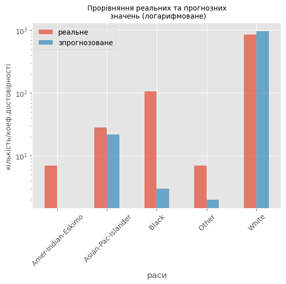

```python
with plt.style.context('ggplot'):
    comparision_table.iloc[:, :2].plot(kind='bar', rot=45, alpha=.7)

    plt.yscale('log')
    plt.title('Прорівняння реальних та прогнозних\n значень (логарифмоване)',
              fontdict={'fontsize': 10})
    plt.xlabel('раси')
    plt.ylabel('кількість/коеф.достовірності', **{'fontsize': 10})

    plt.show()
```

```python
from sklearn.metrics import ConfusionMatrixDisplay
import matplotlib.pyplot as plt

def plot_cm(y, y_pred):
    ConfusionMatrixDisplay.from_predictions(target_chunk, target_pred, display_labels=classes_names)
    plt.xticks(rotation=45, ha='right')
    plt.title("Матриця помилок")
    plt.xlabel("Кількість зпрогнозованих рас")
    plt.ylabel("\nКількість істиних рас")

    plt.show()
```

**Матриця плутанини/помилок** допомагає візуалізувати якість моделі

- *Діагональні елементи* представляють кількість точок, для яких прогнозована мітка дорівнює істинній мітці
- *Недіагональні елементи* — це ті, які неправильно позначені класифікатором.

Чим вищі діагональні значення матриці плутанини, тим краще

# ПИТАННЯ, ПРОПОЗИЦІЇ, ЗАУВАЖЕННЯ ?